# Practical 3: Getting Down with DAGs

Carel F.W. Peeters  
Mathematical & Statistical Methods group – Biometris  
Wageningen University & Research  
**Causal Inference I**

carel.peeters@wur.nl

## Preliminaries

This document contains the 3rd practical for the MSc course **Causal Inference I**. In Lecture 3 we have seen the basic terminology and usage of directed acyclic graphs (DAGs). In this practical we will be gaining some hands-on experience with these graphical objects. The learning goals for this practical are:

1. To practice with DAG terminology;
2. To practice the derivation of testable implications of a given DAG;
3. To practice with the identification of causal effects from a given DAG.

The programming language of choice is R. In the remainder code will be contained in blocks and in-text references to functions, function arguments, and objects will be denoted as `foo`. The code in code-blocks can be directly copied by pressing the *copy to clipboard* button in the upper-right corner. Code may be directly pasted in your R console.

### Packages

Start by setting your working directory to convenience and invoking the required packages. The code below recognizes if certain packages are missing from your package library and, if so, will install them automatically.

```r
## Set working directory to convenience
setwd(" ")

## Install and invoke packages
if(!"dagitty" %in% .packages(all = TRUE)) install.packages("dagitty")
if(!"ggplot2" %in% .packages(all = TRUE)) install.packages("ggplot2")
if(!"GGally" %in% .packages(all = TRUE)) install.packages("GGally")
if(!"gridExtra" %in% .packages(all = TRUE)) install.packages("gridExtra")

## Load packages
library(dagitty)
library(ggplot2)
library(GGally)
library(gridExtra)
```

We will make use of the **dagitty** package to support the exercises. This package supports the drawing and evaluation of structural causal models (DAGs). We will make use of **ggplot2** and **GGally** to support additional plotting of data. In this practical we will be focusing on concepts and understanding rather than programming.

## Exercises

Our first 3 exercises relate to the consecutive learning goals listed above. In Exercise 1 we will practice with the familial language used to understand DAGs and their structure. Exercise 2 we will practice with the derivation of testable implications from a DAG. We will see that we may want to amend or adapt a given DAG after evaluation of the testable implications. In Exercise 3 we will be using DAGs to recognize conditioning sets for the identification of causal effects. In exercises 1-3 we will be using sports data. Exercise 4 is an additional (or take-home) exercise. It shows, through simulated data, that a strong predictor (in the regression sense) does not need to have a causal effect on the outcome of interest.

### Exercise 1: DAGs as a family gathering

We have seen in the Lecture that DAGs are simply graphical objects. Graphical objects are simply collections of nodes (or vertices) and edges (or connections). What makes a graphical object a DAG is when all edges are unidirectional arrows (the directed part) and that, when tracing the directions indicated by those arrows, we never can get back to a node we started from (the acyclic part). Such graphs are used to intuitively represent causal beliefs through present arrows (encoding direct causal influence) as well as missing arrows (encoding the absence of direct causal influence). In order to harness their intuitive power, and in order to understand the ever-growing research literature on DAGs, you need to be comfortable with their terminology. In the lecture we have seen that DAGs draw upon *familial* notions to express causal structure and influence. We will gain some further practice with that here.

Imagine you are a sports medicine researcher specialized in injuries. You amass your knowledge and experience in a DAG that expresses your causal beliefs. You are especially interested in the effect of Warm-Up Exercises (WUE) on Injuries (I). Furthermore, your causal beliefs include the effects of:

- Coach (C);
- Team Motivation (TM);
- Previous Injuries (PI);
- Contact Sports (CS);
- Fitness Level (FL);
- Pre-Game Proprioception (a neuronal measure of sense of self-movement, force, and body position) (PGP);
- Intra-Game Proprioception (IGP);
- Neuromuscular Fatigue (NMF).

We are going to use the `dagitty` function to draw our DAG. A statement like `C [pos="-4.000,-3.000"]` specifies the node `C` as well as its (relative) location. A statement like `C -> { FL TM }` specifies that there is a directed connection from C to FL as well as a directed connection from C to TM. In the code below we explicitly indicate I as our outcome and WUE as our exposure of interest. The following specification then represents and plots your causal beliefs:

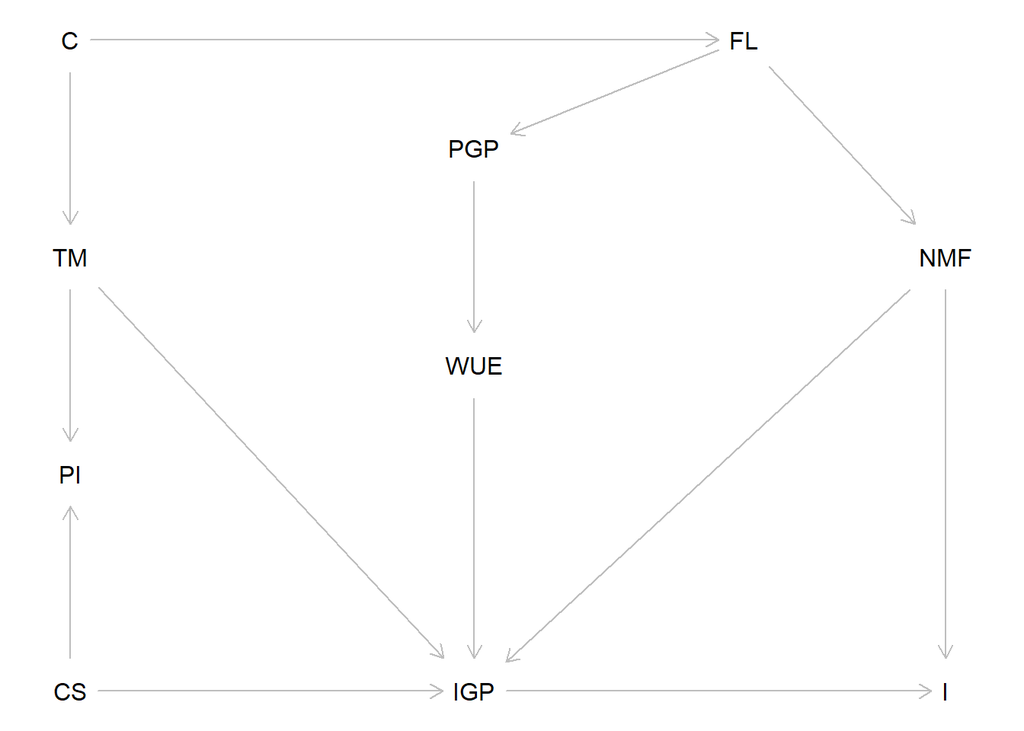

```r
## Specify the DAG
g.postulated <- dagitty('dag {
  C   [pos="-4.000,-3.000"]
  CS  [pos="-4.000,3.000"]
  FL  [pos="1.000,-3.000"]
  I   [outcome,pos="2.500,3.000"]
  IGP [pos="-1.000,3.000"]
  NMF [pos="2.500,-1.000"]
  PGP [pos="-1.000,-2.000"]
  PI  [pos="-4.000,1.000"]
  TM  [pos="-4.000,-1.000"]
  WUE [exposure,pos="-1.000,0.000"]
  C   -> { FL TM }
  CS  -> { IGP PI }
  FL  -> { NMF PGP }
  IGP -> I
  NMF -> { I IGP }
  PGP -> WUE
  TM  -> { IGP PI }
  WUE -> IGP
  }
')

## Plotting DAG
plot(g.postulated)
```

Let us now try to understand this DAG with the use of familial nomenclature as seen during the lecture:

1. Name all the *parents* of IGP.
2. Who are the *ancestors* of I?
3. Who are the *children* of NMF?
4. Name all *descendants* of T.
5. Draw all *directed paths* from C to I.
6. Is IGP a *collider* in the triplet TM, IGP, NMF?

You have probably provided your answers by hand (using some good old-fashioned pen and paper). You can check your answers with some simple functions.

1. We can find all parents of IGP as:

```r
parents( g.postulated, "IGP" )
```

```
[1] "CS"  "NMF" "TM"  "WUE"
```

2. We can find all ancestors of I as:

```r
ancestors( g.postulated, "I" )
```

```
[1] "I"   "NMF" "FL"  "C"   "IGP" "WUE" "PGP" "TM"  "CS"
```

3. We can find all children of NMF as:

```r
children( g.postulated, "NMF" )
```

```
[1] "I"   "IGP"
```

4. We can find all descendants of TM as:

```r
descendants( g.postulated, "TM" )
```

```
[1] "TM"  "PI"  "IGP" "I"
```

5. We can find all directed paths from C to I as:

```r
paths( g.postulated, "C", "I", directed=TRUE )$paths
```

```
[1] "C -> FL -> NMF -> I"               "C -> FL -> NMF -> IGP -> I"
[3] "C -> FL -> PGP -> WUE -> IGP -> I" "C -> TM -> IGP -> I"
```

6. The directed edges from TM and NMF towards IGP indeed collide at IGP. We could check if this is indeed logically true using (where IGP is explicitely given as the midpoint of the triplet):

```r
isCollider( g.postulated, "TM", "IGP","NMF")
```

```
[1] TRUE
```

Note that, by convention, `descendants(graph, node)` and `ancestors(graph, node)` include `node`.

### Exercise 2: Art thou independent?

We will continue with our setting from Exercise 1. After we have drawn a DAG and have understood its structure we may want to evaluate if the DAG is consistent with (the information contained in) data. This is where we evaluate the testable implications of a DAG and see if they hold up in empirical practice. As we know by now, the concept of *d*-separation can be used to assess the restrictions (in terms of conditional and unconditional independencies) that must hold in any dataset generated by a mechanism that has a given DAG as the underlying data generating process. Let us review some of these implications for the DAG given in Exercise 1.

7. Which set of variables *d*-separates C and CS?
8. Which set of variables *d*-separates WUE and I?
9. List as many implied conditional independencies as you can.
7. The empty set. This is because, for example, the collider PI blocks the flow of information between C and CS. Hence, in this case, not conditioning on a collider would leave the path C - TM - PI - CS blocked. This goes for all possible paths between C and CS. Thus,

$$C \perp\!\!\!\perp CS$$

8. It is clear that we must condition on IGP to block the flow of information between WUE and I. In doing so, we open up a path through NMF, as IGP is a collider for WUE and NMF. We then must additionally condition on NMF to render WUE and I independent. Hence:
   $$WUE \perp\!\!\!\perp I \,|\, IGP, NMF.$$
9. I think you got a long way in listing the implied conditional independencies. There are 64 in total. We can obtain them through:

```r
## List all implied conditional independencies
impliedConditionalIndependencies(g.postulated)
```

```
C _||_ CS
C _||_ I | IGP, NMF
C _||_ I | NMF, TM, WUE
C _||_ I | NMF, PGP, TM
C _||_ I | FL, TM
C _||_ IGP | NMF, TM, WUE
C _||_ IGP | NMF, PGP, TM
C _||_ IGP | FL, TM
C _||_ NMF | FL
C _||_ PGP | FL
C _||_ PI | TM
C _||_ WUE | PGP
C _||_ WUE | FL
CS _||_ FL
CS _||_ I | IGP, NMF
CS _||_ NMF
CS _||_ PGP
CS _||_ TM
CS _||_ WUE
FL _||_ I | IGP, NMF
FL _||_ I | NMF, TM, WUE
FL _||_ I | C, NMF, WUE
FL _||_ I | NMF, PGP, TM
FL _||_ I | C, NMF, PGP
FL _||_ IGP | NMF, TM, WUE
FL _||_ IGP | C, NMF, WUE
FL _||_ IGP | NMF, PGP, TM
FL _||_ IGP | C, NMF, PGP
FL _||_ PI | TM
FL _||_ PI | C
FL _||_ TM | C
FL _||_ WUE | PGP
I _||_ PGP | FL, WUE
I _||_ PGP | C, NMF, WUE
I _||_ PGP | NMF, TM, WUE
I _||_ PGP | IGP, NMF
I _||_ PI | CS, TM
I _||_ PI | IGP, NMF
I _||_ TM | IGP, NMF
I _||_ WUE | IGP, NMF
```

[output cut: 9 more lines]

```
NMF _||_ TM | FL
NMF _||_ WUE | PGP
NMF _||_ WUE | FL
PGP _||_ PI | TM
PGP _||_ PI | C
PGP _||_ PI | FL
PGP _||_ TM | C
PGP _||_ TM | FL
PI _||_ WUE | PGP
PI _||_ WUE | FL
PI _||_ WUE | C
PI _||_ WUE | TM
TM _||_ WUE | PGP
TM _||_ WUE | FL
TM _||_ WUE | C
```

We have collected empirical data on the variables of interest from *n* = 500 athletes. The variables all pertain to continuous measurements and have been standardized. These data are available in the `data` object from the `sportsData.RData` file on BrightSpace. This means that we can test whether our DAG is consistent with the data at hand. Let us first load and visually inspect the data:

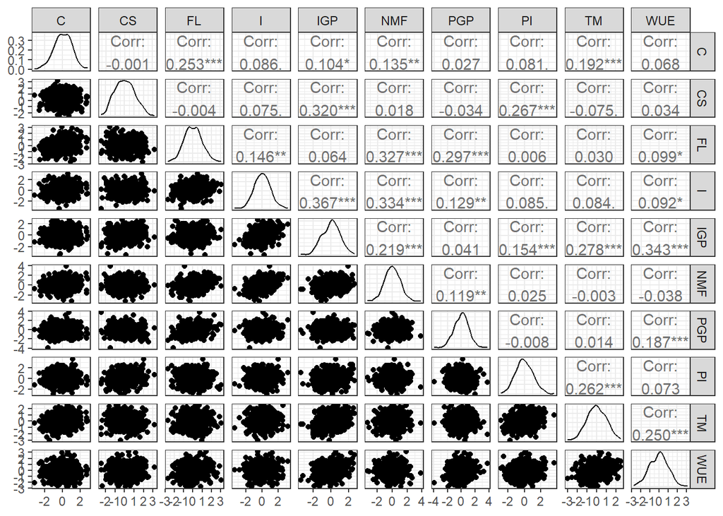

```r
## Load and inspect data
load("sportsData.RData")
ggpairs(data)+ theme_bw()
```

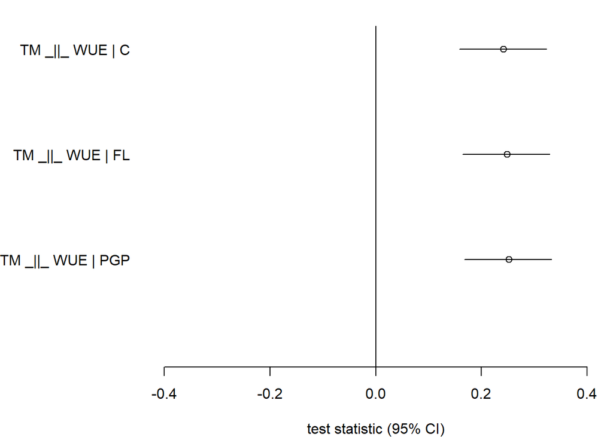

```r
## Perform local tests
r <- localTests(g.postulated, data)

## Adjust using Holm-Bonferroni correction
## Retain only those tests with adjusted p-value < .05
r <- r[p.adjust(r$p.value) < 0.05, ]

## Plot conditional independencies inconsistent with data
r <- r[order(r$p.value), ]
par(mar = c(4, 8.5, 1.5, 0.5))
plotLocalTestResults(r, bty = "n", xlim = c(-0.4, 0.4), ylim = c(0.1, 3.1),
                     axis.pars = list(las = 1, lty = 0))
```

10. Why would we perform a multiple testing correction?
11. What are your conclusions based on the output?
12. Say that we assume that the inconsistencies noticed in 11 are not due to measurement error nor due to unmeasured (latent) variables. How should you then amend your DAG given these conclusions?
10. As we have many testable implications (64) we would be capitalizing on chance without corrections. We use Holm-Bonferroni as it makes no assumption of independence between the consecutive tests.
11. Looking at the output we see that we have 3 implied conditional independencies whose empirical partial correlation is clearly nonzero. Hence *T**M* ⊥ *W**U**E* | *C*, *T**M* ⊥ *W**U**E* | *F**L*, and *T**M* ⊥ *W**U**E* | *P**G**P* are found to be inconsistent with the collected data.
12. All inconsistencies pertain to TM and WUE. The inconsistencies imply that TM cannot be made independent from WUE. Hence, a directed link from TM to WUE should be included. Indeed, you could also include an edge from WUE to TM, which would also be consistent with the concurrent conditional independencies and the data. From a substantive viewpoint, however, an edge from TM to WUE seems more logical. This stresses the importance of the incorporation of expert/substantive knowledge in causal reasoning.

### Exercise 3: Adjustment is the name of the game

We amend our graph to represent our updated DAG consistent with the empirical data. We will use this updated DAG to find relevant adjustment sets for the causal effect of WUE on I. Let us plot the amended DAG first:

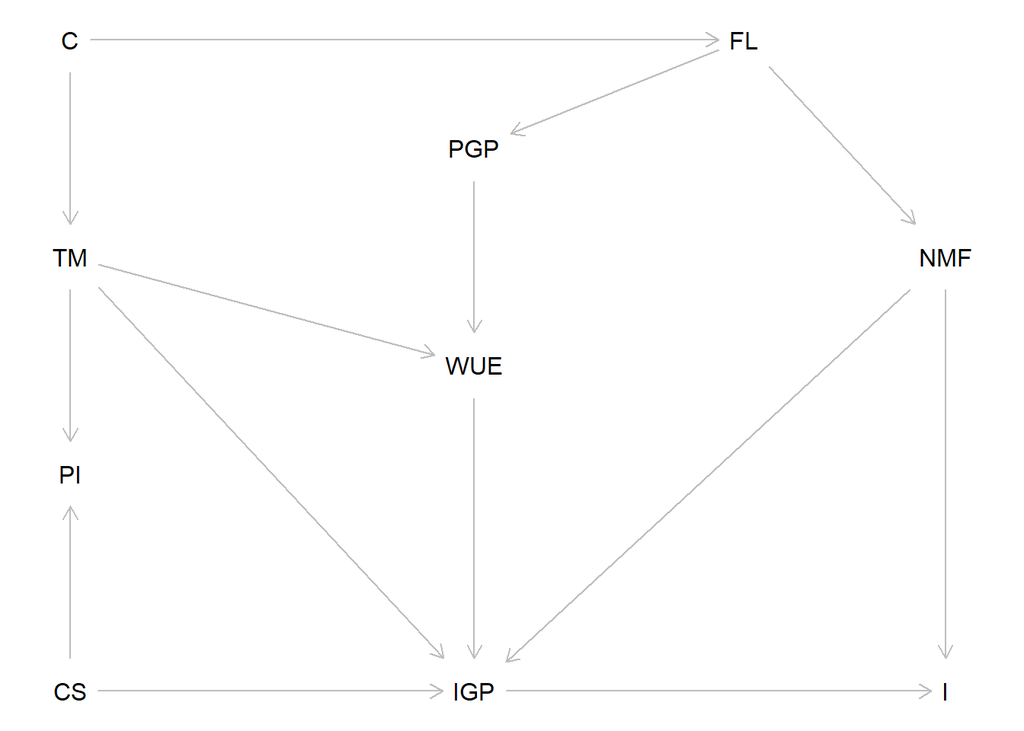

```r
## Amended DAG
g.amended <- dagitty('dag {
  C   [pos="-4.000,-3.000"]
  CS  [pos="-4.000,3.000"]
  FL  [pos="1.000,-3.000"]
  I   [outcome,pos="2.500,3.000"]
  IGP [pos="-1.000,3.000"]
  NMF [pos="2.500,-1.000"]
  PGP [pos="-1.000,-2.000"]
  PI  [pos="-4.000,1.000"]
  TM  [pos="-4.000,-1.000"]
  WUE [exposure,pos="-1.000,0.000"]
  C   -> { FL TM }
  CS  -> { IGP PI }
  FL  -> { NMF PGP }
  IGP -> I
  NMF -> { I IGP }
  PGP -> WUE
  TM  -> { IGP PI WUE}
  WUE -> IGP
  }
')

## Plotting amended DAG
plot(g.amended)
```

In the lecture we have discussed the backdoor criterion and its importance. This criterion can be used to determine which covariate adjustments sets are required to remove structural confounding bias. Focus on the amended DAG and answer the following question:

13. Can you list at least 3 sets of variables that satisfy the backdoor criterion to determine the causal effect of WUE on I?
13. There a quite many adjustment sets that satisfy the backdoor criterion. We can list them all through the following call (in which we do not have to specify the exposure and outcome explicitly as we have done that in the `g.amended` object):

```r
## Listing all adjustment sets
adjustmentSets( g.amended, type = "all" )
```

```
{ FL, TM }
{ C, FL, TM }
{ CS, FL, TM }
{ C, CS, FL, TM }
{ NMF, TM }
{ C, NMF, TM }
{ CS, NMF, TM }
{ C, CS, NMF, TM }
{ FL, NMF, TM }
{ C, FL, NMF, TM }
{ CS, FL, NMF, TM }
{ C, CS, FL, NMF, TM }
{ PGP, TM }
{ C, PGP, TM }
{ CS, PGP, TM }
{ C, CS, PGP, TM }
{ FL, PGP, TM }
{ C, FL, PGP, TM }
{ CS, FL, PGP, TM }
{ C, CS, FL, PGP, TM }
{ NMF, PGP, TM }
{ C, NMF, PGP, TM }
{ CS, NMF, PGP, TM }
{ C, CS, NMF, PGP, TM }
{ FL, NMF, PGP, TM }
{ C, FL, NMF, PGP, TM }
{ CS, FL, NMF, PGP, TM }
{ C, CS, FL, NMF, PGP, TM }
{ FL, PI, TM }
{ C, FL, PI, TM }
{ CS, FL, PI, TM }
{ C, CS, FL, PI, TM }
{ NMF, PI, TM }
{ C, NMF, PI, TM }
{ CS, NMF, PI, TM }
{ C, CS, NMF, PI, TM }
{ FL, NMF, PI, TM }
{ C, FL, NMF, PI, TM }
{ CS, FL, NMF, PI, TM }
{ C, CS, FL, NMF, PI, TM }
{ PGP, PI, TM }
{ C, PGP, PI, TM }
{ CS, PGP, PI, TM }
{ C, CS, PGP, PI, TM }
{ FL, PGP, PI, TM }
{ C, FL, PGP, PI, TM }
{ CS, FL, PGP, PI, TM }
{ C, CS, FL, PGP, PI, TM }
{ NMF, PGP, PI, TM }
{ C, NMF, PGP, PI, TM }
{ CS, NMF, PGP, PI, TM }
{ C, CS, NMF, PGP, PI, TM }
{ FL, NMF, PGP, PI, TM }
{ C, FL, NMF, PGP, PI, TM }
{ CS, FL, NMF, PGP, PI, TM }
{ C, CS, FL, NMF, PGP, PI, TM }
```

You have probably noted that there are quite many adjustment sets that satisfy the backdoor criterion. This is why it is useful to introduce the notion of the *minimal adjustment set*: A minimal set that satisfies the backdoor criterion is any set of variables that satisfies the backdoor criterion that, if any of the variables would be removed from the set, it would no longer satisfy the backdoor criterion.

14. Can you list the minimal adjustment sets of variables that satisfy the backdoor criterion to determine the causal effect of WUE on I?
14. The number of minimal adjustment sets is much smaller. You can check your answer with the following call (the default call to `adjustmentSets` lists the minimal sets only):

```r
## Listing all adjustment sets
adjustmentSets(g.amended)
```

```
{ NMF, TM }
{ FL, TM }
{ PGP, TM }
```

As you will notice, at least one of the minimal sets is a subset of all possible adjustment sets found in 13.

### Additional (take-home) exercise: Predictor without a cause

During the lecture we learned that causal DAGs can be understood as structural equation models. Let us have a look at a simple structural equation system:
$$\begin{aligned} X &:= \epsilon_{X} \\ Y &:= X + \epsilon_{Y} \\ Z &:= Y + \epsilon_{Z}, \end{aligned}$$
with *ϵ*<sub>*X*</sub> ∼ 𝒩(0,1), *ϵ*<sub>*Y*</sub> ∼ 𝒩(0,1), and *ϵ*<sub>*Z*</sub> ∼ 𝒩(0,0.1). In the causal structural model literature, the symbol $:=$ implies causal assignment. Hence, *X* is measured with random error, *Y* is causally influenced by *X*, and *Z* is causally influenced by *Y*. Let us generate and plot some data according to this model.

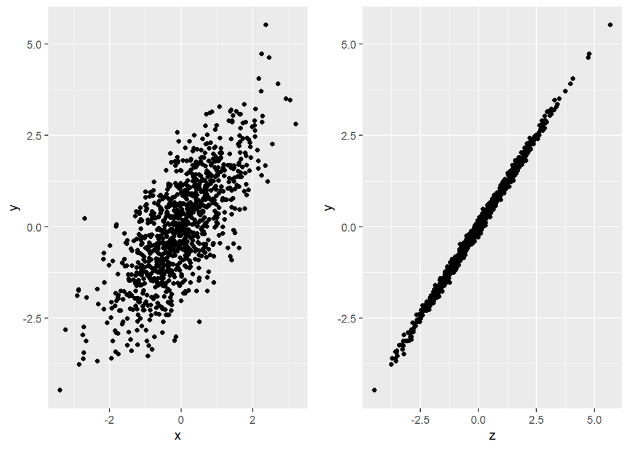

```r
## Generate and plot data
set.seed(1234)
n <- 1000
x <- rnorm(n, 0, 1)
y <- x + rnorm(n, 0, 1)
z <- y + rnorm(n, 0, 0.1)
DAT <- data.frame(x,y,z)
xyplot <- ggplot(DAT, aes(x = x, y = y)) + geom_point()
zyplot <- ggplot(DAT, aes(x = z, y = y)) + geom_point()
grid.arrange(xyplot, zyplot, ncol = 2)
```

15. Which, from a regression standpoint, would be a better predictor for *Y*: *X* or *Z*?
16. It is clear, from our simulation, that *Z* does not have a causal effect on *Y*. What does this small example convey?
15. Clearly, *Y* has a weaker association with *X* than with *Z*. Hence, *Z* is therefore more relevant when it comes to prediction (from a regression perspective). This is immediate from the figures. We can also conclude this from regressing *Y* on *X* and regressing *Y* on *Z*:

```r
## Regress
summary(lm(y ~ x, data = DAT))
```

```
Call:
lm(formula = y ~ x, data = DAT)

Residuals:
    Min      1Q  Median      3Q     Max
-3.1661 -0.6439  0.0145  0.6537  3.0684

Coefficients:
            Estimate Std. Error t value Pr(>|t|)
(Intercept)  0.01599    0.03100   0.516    0.606
x            1.05571    0.03109  33.954   <2e-16 ***
---
Signif. codes:  0 '***' 0.001 '**' 0.01 '*' 0.05 '.' 0.1 ' ' 1

Residual standard error: 0.9801 on 998 degrees of freedom
Multiple R-squared:  0.536, Adjusted R-squared:  0.5355
F-statistic:  1153 on 1 and 998 DF,  p-value: < 2.2e-16
```

```r
summary(lm(y ~ z, data = DAT))
```

```
Call:
lm(formula = y ~ z, data = DAT)

Residuals:
      Min        1Q    Median        3Q       Max
-0.304275 -0.068659 -0.002899  0.070714  0.309222

Coefficients:
             Estimate Std. Error t value Pr(>|t|)
(Intercept) -0.002932   0.003198  -0.917    0.359
z            0.995975   0.002221 448.415   <2e-16 ***
---
Signif. codes:  0 '***' 0.001 '**' 0.01 '*' 0.05 '.' 0.1 ' ' 1

Residual standard error: 0.1011 on 998 degrees of freedom
Multiple R-squared:  0.9951,    Adjusted R-squared:  0.9951
F-statistic: 2.011e+05 on 1 and 998 DF,  p-value: < 2.2e-16
```

16. It conveys that a variable that does not have a causal effect on an outcome of interest can, irrespective of the absence of causal influence, be a strong predictor in the regression sense. Hence, one should treat the workhorse of regression with care when causal inference is the goal.

### Assignment

Work with your group on Part 3 of the Assignment:

1. Make a DAG for your research question. You can do that using *expert* knowledge, where you may consider yourself the expert.
2. Assess if your DAG implies conditional independencies that are inconsistent with the data. Do you need to adjust your DAG? (Tip: you can again use the `localTests` function for that. In case of categorical data, you can use the argument `type="cis.chisq"`).
3. Use your (adjusted) DAG to specify for which variables you need to adjust in order to estimate the causal effect tied to your research question.

## Recap and look ahead

DAGs encode qualitative causal beliefs in graphical objects. A DAG gives intuitive access to the testable implications underlying causal beliefs. Moreover, DAGs are very useful for identifying confounding variables that require conditioning when estimating causal effects. The topic of estimation of causal effects will be the focus of the next lecture and practical.

Note that an absence of violations of the testable implications of a DAG does not equate to proof that the DAG is correct. In fact, there may be equivalent DAGs: different DAGs (with differing causal implications) that carry the same testable implications. It is important to realize that it is the belief in a given causal syntax that makes a DAG (and subsequent analyzes) causal. These and other issues are beyond the scope of this course. If you [really like DAGs](https://www.youtube.com/watch?v=zH64dlgyydM), you will learn more about them in the elective course Causal Inference II.